# Labo 9

Oscar Centeno Mora

# Text mining descriptivo

1. Paquetes y funciones
2. Datos del laboratorio (fuentes de datos)
3. Limpieza y la tokenización
4. Análisis descriptivo del texto
5. Nube de palabras
6. Relaciones de palabras
7. Análisis de sentimiento
8. Otros análisis: clustering + relación de términos
9. Web scraping

## Sitios web de referencia y datos del laboratorio

Los siguientes enlaces son referentes al análisis de texto descriptivo:

https://www.tidytextmining.com/ https://rpubs.com/jboscomendoza/analisis_sentimientos_lexico_afinn  
https://rpubs.com/jboscomendoza/mineria-de-textos-con-r  
https://rpubs.com/jboscomendoza/coheed_and_cambria  
https://rpubs.com/pjmurphy/265713 https://medium.com/@actsusanli/text-mining-is-fun-with-r-35e537b12002 https://rpubs.com/Joaquin_AR/334526 https://blogs.solidq.com/es/advanced-analytics/introduccion-al-text-mining-con-r-parte-i/  
https://rpubs.com/cbpuschmann/textmining  
https://rpubs.com/cruzcancel/238997 https://rpubs.com/novrisuhermi/twitter_text_mining_2 http://www.rpubs.com/peg/136839 https://rpubs.com/HAVB/tangos

## Datos del laboratorio

Estos son los datos que se utilizarán en el laboratorio

### Análisis de Gloriana

Análisaremos a Gloriana, lo cual alguien describió como:

Gloriana, mujer joven y hermosa nacida en 1985 es una de las mejores, o tal vez la mejor medica general de nuestro pais. En sus estudios de maestria obtuvo la mejor calificacion de la generacion, y sus actos quedaron felicitados por sus profesores y compañeros. Ahora Gloriana debe seguir adelante demostrando su gran valentia, esfuerzo, pasión y dedicación para la medicina. Ella es Gloriana, o tambien abrebiada como GMC.

### Carta de Mujica

Analizaremos un discurso pronunciado por José Mujica en la cumbre Río+20. Este archivo se llama es “mojicadis2.txt”

### Análisis del libro Nible de Miguel de Unamuno

El texto con el que trabajeremos es el texto del libro Niebla de Miguel de Unamuno que se puede descargar en Gutenberg en el siguiente enlace:

https://www.gutenberg.org/files/49836/49836-0.txt

Nosotros utilizaremos el archivo “49836-0.txt”

### Análisis de cantidatos a la presidencia en México

Descargamos los datos con los tuits de los candidatos a la presidencia desde la siguiente dirección, estos han sido obtenidos usando la API de Twitter.

https://raw.githubusercontent.com/jboscomendoza/rpubs/master/sentimientos_afinn/tuits_candidatos.csv

### Análisis de un sitio web

La información será el sitio MusicBrainz, un portal que compila metadatos musicales. Desde aquí podemos recuperar los metadatos de la discografía de Coheed and Cambria, es decir: la lista de canciones, el título del disco, y la fecha de publicación.

https://musicbrainz.org/release/5e5dad52-a3cf-4cf7-a222-6f4bca6b17ef

## Librerías del análisis de texto

Veamos las librerías más utilizadas por R para llevar a cabo el análisis de Text Mining.

### stringr

Paquete desarrollado por Hadley Wickham con multitud de funciones (división, búsqueda, reemplazo…) para trabajar con strings.

https://cran.r-project.org/web/packages/stringr/vignettes/stringr.html

### tidytext

Paquete desarrollado por Julia Silge y David Robinson. Los autores proponen una forma de trabajar con texto que sigue los principios de tidy data, lo que hace muy sencillo combinarlo con otros paquetes tales como dplyr, broom, tidyr y ggplot2.

https://cran.r-project.org/web/packages/tidytext/vignettes/tidytext.html

### quanteda

Paquete con multitud de funciones orientadas a text mining, algunas de ellas permiten crear Term-Document Matrices

https://quanteda.io/ https://cran.r-project.org/web/packages/quanteda/quanteda.pdf

### purrr

Permite aplicar funciones a elementos de un vector o lista, por ejemplo, a los elementos de una columna de un dataframe.

https://purrr.tidyverse.org/

## Carga de Datos

### Análisis de Gloriana

Sea la introducción del texto sobre Gloriana

```r
text <- c("Gloriana, mujer joven y hermosa nacida en 1985 es una de las-",
          "mejores, o tal vez la mejor medica general de nuestro pais. En-",
          "sus estudios de maestria obtuvo la mejor calificacion de la-",
          "generacion, y sus actos quedaron felicitados por sus profesores y",
          "compañeros. Ahora Gloriana debe seguir adelante demostrando su gran",
          "valentia, esfuerzo, pasión y dedicación para la medicina.",
          "Ella es Gloriana, o también abrebiada como GMC.")

text
```

```
## [1] "Gloriana, mujer joven y hermosa nacida en 1985 es una de las-"
## [2] "mejores, o tal vez la mejor medica general de nuestro pais. En-"
## [3] "sus estudios de maestria obtuvo la mejor calificacion de la-"
## [4] "generacion, y sus actos quedaron felicitados por sus profesores y"
## [5] "compañeros. Ahora Gloriana debe seguir adelante demostrando su gran"
## [6] "valentia, esfuerzo, pasión y dedicación para la medicina."
## [7] "Ella es Gloriana, o también abrebiada como GMC."
```

¿Será válido analizar lo dicho sobre Gloriana?

### Carta de Mujica

Analizaremos un discurso pronunciado por José Mujica en la cumbre Río+20.

Utilizamos la función “readLines”"

```r
setwd("C:/Users/oscar.centeno/Desktop/TM")

mujica <- suppressWarnings(paste(readLines("mojicadis2.txt"), collapse=" "))

text <- data.frame(doc_id = "Dis Mujica2", text = mujica)
ds <- DataframeSource(text)
```

Finalmente, en archivo .txt, para su previo análisis debemos establecer el archivo como un Corpus

```r
corpus <- Corpus(ds)
corpus
```

```
## <<SimpleCorpus>>
## Metadata:  corpus specific: 1, document level (indexed): 0
## Content:  documents: 1
```

Sin embargo nos hace falta limpiarlo….

### Carta de Obama y de Trump

```r
obama <- suppressWarnings(paste(readLines("Discurso_obama.txt"), collapse=" "))
trump <- suppressWarnings(paste(readLines("Discurso_trump.txt"), collapse=" "))

text.obama <- data.frame(doc_id = "Dis obama", text = obama)
ds.obama <- DataframeSource(text.obama)
text.trump <- data.frame(doc_id = "Dis trump", text = trump)
ds.trump <- DataframeSource(text.trump)
```

### Análisis del libro Nible de Miguel de Unamuno

Bajo el texo Nible, archivo “49836-0.txt”, realizamos el cargamiento del libro.

```r
setwd("C:/Users/oscar.centeno/Desktop/TM")

nov_raw <- read_lines("49836-0.txt", skip = 419, n_max = 8313-419)
```

¿Cuál es el contenido de un texto .txt? Veamos

```r
str(nov_raw)
```

```
##  chr [1:7894] "NIEBLA" "" "" "" "" "I" "" "" ...
```

¿Qué podemos decir? ¿Cómo podemos acomodar el archivo para que sea un archivo analizable?

Al analizar libros tan grandes y extensos, debemos acomodar un tanto el Corpus en párrafos:

```r
diez <- rep(1:ceiling(length(nov_raw)/10), each = 10)
diez <- diez[1:length(nov_raw)]
nov_text <- cbind(diez, nov_raw) %>% data.frame()
nov_text <- aggregate(formula = nov_raw ~ diez,
                      data = nov_text,
                      FUN = paste,
                      collapse = " ")
nov_text <- nov_text %>% as.matrix

# nov_text <- as.matrix(nov_text)

dim(nov_text)
```

```
## [1] 790   2
```

EL siguiente paso sería limpiar los datos….

### Análisis de cantidatos a la presidencia en México

A partir de una descarga de Tweets del siguiente enlace, descargaremos los datos y el Sentiment Lexicon.

https://raw.githubusercontent.com/jboscomendoza/rpubs/master/sentimientos_afinn/tuits_candidatos.csv

Primero se define un tema…

```r
#Definir tema

tema_graf <-
  theme_minimal() +
  theme(text = element_text(family = "serif"),
        panel.grid.minor = element_blank(),
        strip.background = element_rect(fill = "#EBEBEB", colour = NA),
        legend.position = "none",
        legend.box.background = element_rect(fill = "#EBEBEB", colour = NA))
```

Descargamos los datos

```r
#Importar datos

download.file("https://raw.githubusercontent.com/jboscomendoza/rpubs/master/sentimientos_afinn/tuits_candidatos.csv",
              "tuits_candidatos.csv")

tuits <- read.csv("tuits_candidatos.csv", stringsAsFactors = F, fileEncoding = "latin1") %>%
  tbl_df()
```

Descargamos el Sentimento Lexicon

```r
#Lexicoon

download.file("https://raw.githubusercontent.com/jboscomendoza/rpubs/master/sentimientos_afinn/lexico_afinn.en.es.csv",
              "lexico_afinn.en.es.csv")

afinn <- read.csv("lexico_afinn.en.es.csv", stringsAsFactors = F, fileEncoding = "latin1") %>%
  tbl_df()
```

Finalmente (fuera del contenido del curso), se preparan los tweets para el análisis

```r
#Preparando los datos

tuits <-
  tuits %>%
  separate(created_at, into = c("Fecha", "Hora"), sep = " ") %>%
  separate(Fecha, into = c("Dia", "Mes", "Periodo"), sep = "/",
           remove = FALSE) %>%
  mutate(Fecha = dmy(Fecha),
         Semana = week(Fecha) %>% as.factor(),
         text = tolower(text)) %>%
  filter(Periodo == 2018)

#Convertir tuits en palabras

tuits_afinn <-
  tuits %>%
  unnest_tokens(input = "text", output = "Palabra") %>%
  inner_join(afinn, ., by = "Palabra") %>%
  mutate(Tipo = ifelse(Puntuacion > 0, "Positiva", "Negativa")) %>%
  rename("Candidato" = screen_name)


# Obtenemos también una puntuación por tuit, usando group_by() y summarise() de dplyr,
# y la agregamos tuits para usarla después. Tambien asignamos a los tuits sin puntuación
# positiva o negativa un valor de 0, que indica neutralidad. Por último cambiamos el
#nombre de la columna screen_name a Candidato

tuits <-
  tuits_afinn %>%
  group_by(status_id) %>%
  summarise(Puntuacion_tuit = mean(Puntuacion)) %>%
  left_join(tuits, ., by = "status_id") %>%
  mutate(Puntuacion_tuit = ifelse(is.na(Puntuacion_tuit), 0, Puntuacion_tuit)) %>%
  rename("Candidato" = screen_name)
```

### Análisis de un sitio web

La información será el sitio MusicBrainz, un portal que compila metadatos musicales. Desde aquí podemos recuperar los metadatos de la discografía de Coheed and Cambria, es decir: la lista de canciones, el título del disco, y la fecha de publicación.

Usamos la función read_html() de rvest, que lee el código html de una página web, a partir de su URL. Asignaremos al objeto musicbrainz_html el resultado de leer el código HTML de la página en la que se encuentran los metadatos del disco “The Afterman: Descencion”.

```r
musicbrainz_html <- read_html("https://musicbrainz.org/release/5e5dad52-a3cf-4cf7-a222-6f4bca6b17ef")
```

## Limpieza de datos y la tokenización

Una vez cargados los datos, lo siguientes es limpiarlos, y luego hacerlos analizables (tokenizarlos). Dentro de la limpieza se podría proceder mediante funciones aisladas, o construir una función que todo lo haga.

### Limpieza de datos : Funciones individuales

Necesitamos limpiar el texto de caracteres que son de poca utilidad en la mineria de textos. Empezamos por aseguramos de que no queden caracteres especiales de la codificación, como saltos de línea y tabulaciones, con un poco de ayuda de Regular Expressions.

```r
nov_text = "Esto es 1 ejemplo de l'limpieza de6 TEXTO  https://t.co/rnHPgyhx4Z @JoaquinAmatRodrigo #textmining"
```

```r
nov_text <- gsub("[[:cntrl:]]", " ", nov_text)
```

Convertimos todo a minúsculas.

```r
nov_text <- tolower(nov_text)
```

Usamos removeWords con stopwords(“spanish”) para eliminar palabras vacias, es decir, aquellas con poco valor para el análisis, tales como algunas preposiciones y muletillas.

```r
nov_text <- removeWords(nov_text, words = stopwords("spanish"))
```

Nos deshacemos de la puntuación, puesto que fin y fin. son identificadas como palabras diferentes, lo cual no deseamos.

```r
nov_text <- removePunctuation(nov_text)
```

En este caso, removemos los números, pues en Niebla no hay fechas y otras cantidades que deseemos conservar.

```r
nov_text <- removeNumbers(nov_text)
```

Por último eliminamos los espacios vacios excesivos, muchos de ellos introducidos por las transformaciones anteriores.

```r
nov_text <- stripWhitespace(nov_text)
```

Finalmente

```r
nov_text
```

```
## [1] " ejemplo llimpieza de texto httpstcornhpgyhxz joaquinamatrodrigo textmining"
```

Y este texto ya limpio puede ser tokenizado

### Función conjunta

Tal vez es mejor hacer una función con todo lo anterior

```r
limpiar_tokenizar <- function(texto){
  # El orden de la limpieza no es arbitrario
    # Se convierte todo el texto a minúsculas
    nuevo_texto <- tolower(texto)
    # Eliminación de páginas web (palabras que empiezan por "http." seguidas
    # de cualquier cosa que no sea un espacio)
    nuevo_texto <- str_replace_all(nuevo_texto,"http\\S*", "")
    # Eliminación de signos de puntuación
    nuevo_texto <- str_replace_all(nuevo_texto,"[[:punct:]]", " ")
    # Eliminación de números
    nuevo_texto <- str_replace_all(nuevo_texto,"[[:digit:]]", " ")
    # Eliminación de espacios en blanco múltiples
    nuevo_texto <- str_replace_all(nuevo_texto,"[\\s]+", " ")
    # Tokenización por palabras individuales
    nuevo_texto <- str_split(nuevo_texto, " ")[[1]]
    # Eliminación de tokens con una longitud < 2
    nuevo_texto <- keep(.x = nuevo_texto, .p = function(x){str_length(x) > 1})
    return(nuevo_texto)
}

test = "Esto es 1 ejemplo de l'limpieza de6 TEXTO  https://t.co/rnHPgyhx4Z @JoaquinAmatRodrigo #textmining"
limpiar_tokenizar(texto = test)
```

```
## [1] "esto"               "es"                 "ejemplo"
## [4] "de"                 "limpieza"           "de"
## [7] "texto"              "joaquinamatrodrigo" "textmining"
```

Y tenemos un texto limpio y toquenizado

### La tokenización

Analicemos nuevamente el caso de Gloriana

```r
text <- c("Gloriana, mujer joven y hermosa nacida en 1985 es una de las-",
          "mejores, o tal vez la mejor medica general de nuestro pais. En-",
          "sus estudios de maestria obtuvo la mejor calificacion de la-",
          "generacion, y sus actos quedaron felicitados por sus profesores y",
          "compañeros. Ahora Gloriana debe seguir adelante demostrando su gran",
          "valentia, esfuerzo, pasión y dedicación para la medicina.",
          "Ella es Gloriana, o también abrebiada como GMC.")


text
```

```
## [1] "Gloriana, mujer joven y hermosa nacida en 1985 es una de las-"
## [2] "mejores, o tal vez la mejor medica general de nuestro pais. En-"
## [3] "sus estudios de maestria obtuvo la mejor calificacion de la-"
## [4] "generacion, y sus actos quedaron felicitados por sus profesores y"
## [5] "compañeros. Ahora Gloriana debe seguir adelante demostrando su gran"
## [6] "valentia, esfuerzo, pasión y dedicación para la medicina."
## [7] "Ella es Gloriana, o también abrebiada como GMC."
```

Ahora, queremos tokenizar. Utilizamos tibble para formar nuestro archivo, y con unnest_tokens tokenizamos.

```r
text_df <- tibble(line = 1:7, text = text)


conteo <- text_df %>%
  unnest_tokens(word, text)

conteo
```

```
## # A tibble: 69 x 2
##     line word
##    <int> <chr>
##  1     1 gloriana
##  2     1 mujer
##  3     1 joven
##  4     1 y
##  5     1 hermosa
##  6     1 nacida
##  7     1 en
##  8     1 1985
##  9     1 es
## 10     1 una
## # ... with 59 more rows
```

Y vemos que ya tokenizamos

```r
conteo %>%
  count(word, sort = TRUE)
```

```
## # A tibble: 52 x 2
##    word         n
##    <chr>    <int>
##  1 de           4
##  2 la           4
##  3 y            4
##  4 gloriana     3
##  5 sus          3
##  6 en           2
##  7 es           2
##  8 mejor        2
##  9 o            2
## 10 1985         1
## # ... with 42 more rows
```

### Limpieza de la carta de Mujica

Si vemos la carta de Mujica en la cumbre de Rio, vemos que no está del todo analizable

```r
mujica <- suppressWarnings(paste(readLines("mojicadis2.txt"), collapse=" "))

text <- data.frame(doc_id = "Dis Mujica2", text = mujica)
text
```

```
##        doc_id
## 1 Dis Mujica2
##                                                                                                                                                                                                                                                                                                          …
## 1 Discurso pronunciado por José Mujica en la cumbre Río+20 Autoridades presentes de todas la latitudes y organismos, muchas gracias. Muchas gracias al pueblo de Brasil y a su Sra. Presidenta, Dilma Rousseff. Muchas gracias a la buena fe que, seguramente, han manifestado todos los oradores que me …
```

Procedamos a limpiarla y generar la matriz de términos

```r
### Limpieza de texto
corpus <- Corpus(ds)
# Eliminar signos de puntuación
corpus <- tm_map(corpus,removePunctuation)
# Texto a minúsculas
corpus <- tm_map(corpus,tolower)
# Eliminar numeros
corpus <- tm_map(corpus,removeNumbers)
# Eliminar palabras vacías del idioma español
corpus <- tm_map(corpus, removeWords, stopwords("spanish"))

# Transformar el texto a texto plano
corpus <- tm_map(corpus, PlainTextDocument)
# Generando  la matriz de términos
term_document_matrix <- TermDocumentMatrix(corpus)
term_document_matrix <- as.matrix(term_document_matrix)
terms.vector <- sort(rowSums(term_document_matrix), decreasing = TRUE)
term_document_data_frame <- data.frame(word = names(terms.vector), freq = terms.vector)
```

```r
term_document_data_frame
```

```
##                            word freq
## consumo                 consumo    6
## mercado                 mercado    6
## vida                       vida    6
## horas                     horas    5
## planeta                 planeta    5
## carácter               carácter    4
## economía               economía    4
## felicidad             felicidad    4
## millones               millones    4
## tener                     tener    4
## ambiente               ambiente    3
## civilización       civilización    3
## cosas                     cosas    3
## cuotas                   cuotas    3
## desarrollo           desarrollo    3
## digo                       digo    3
## globalización     globalización    3
## gracias                 gracias    3
## hacer                     hacer    3
## hombre                   hombre    3
## humana                   humana    3
## medio                     medio    3
## mil                         mil    3
## muchas                   muchas    3
## país                       país    3
## posible                 posible    3
## ser                         ser    3
## sino                       sino    3
## sociedades           sociedades    3
## acompañar             acompañar    2
## acuerdos               acuerdos    2
## así                         así    2
## bien                       bien    2
## causa                     causa    2
## competencia         competencia    2
## creado                   creado    2
## crisis                   crisis    2
## darnos                   darnos    2
## deparado               deparado    2
```

[output cut: 249 more lines]

```
## voluntad               voluntad    1
## volver                   volver    1
## voz                         voz    1
## ¿cuánto                 ¿cuánto    1
## época                     época    1
## íntima                   íntima    1
## –                             –    1
## –epicúreo             –epicúreo    1
## “                             “    1
## “monumento           “monumento    1
## “plus”                   “plus”    1
## “pobre                   “pobre    1
## “rechinan”           “rechinan”    1
## “úselo                   “úselo    1
## ”                             ”    1
```

### Limpieza Cartas de Obama y de Trump

```r
### Limpieza de texto
corpus.obama <- Corpus(ds.obama)
corpus.trump <- Corpus(ds.trump)
# Eliminar signos de puntuación
corpus.obama <- tm_map(corpus.obama,removePunctuation)
corpus.trump <- tm_map(corpus.trump,removePunctuation)
# Texto a minúsculas
corpus.obama <- tm_map(corpus.obama,tolower)
corpus.trump <- tm_map(corpus.trump,tolower)
# Eliminar numeros
corpus.obama <- tm_map(corpus.obama,removeNumbers)
corpus.trump <- tm_map(corpus.trump,removeNumbers)
# Eliminar palabras vacías del idioma español
corpus.obama <- tm_map(corpus.obama, removeWords, stopwords("spanish"))
corpus.trump <- tm_map(corpus.trump, removeWords, stopwords("spanish"))

# Transformar el texto a texto plano
corpus.obama <- tm_map(corpus.obama, PlainTextDocument)
corpus.trump <- tm_map(corpus.trump, PlainTextDocument)
# Genera la matriz de términos
term_document_matrix.obama <- TermDocumentMatrix(corpus.obama)
term_document_matrix.obama <- as.matrix(term_document_matrix.obama)
terms.vector.obama <- sort(rowSums(term_document_matrix.obama), decreasing = TRUE)
term_document_data_frame.obama <- data.frame(word = names(terms.vector.obama), freq = terms.vector.obama)

term_document_matrix.trump <- TermDocumentMatrix(corpus.trump)
term_document_matrix.trump <- as.matrix(term_document_matrix.trump)
terms.vector.trump <- sort(rowSums(term_document_matrix.trump), decreasing = TRUE)
term_document_data_frame.trump <- data.frame(word = names(terms.vector.trump), freq = terms.vector.trump)
```

### Limpieza del libro Niebla de Miguel de Unamuno

Necesitamos limpiar el texto de caracteres que son de poca utilidad en la mineria de textos.

Empezamos por aseguramos de que no queden caracteres especiales de la codificación, como saltos de línea y tabulaciones, con un poco de ayuda de Regular Expressions.

```r
nov_text <- gsub("[[:cntrl:]]", " ", nov_text)
nov_text <- removeNumbers(nov_text)
nov_text <- stripWhitespace(nov_text)
nov_text <- tolower(nov_text)
nov_text <- removeWords(nov_text, words = stopwords("spanish"))
nov_text <- removePunctuation(nov_text)
```

## Definición del corpus y matriz de términos

Una vez se haya preparado el documentos (limpieza y tokenización), se procede a crear el Corpus, es decir, el acervo del documento a analizar.

### Corpus del libro Niebla

En nuestro caso, nuestro Corpus se compone de todos los parrafos del libro Niebla y los asignaremos al objeto nov_corpus usando las funciones VectorSource y Corpus.

```r
setwd("C:/Users/oscar.centeno/Desktop/TM")

nov_raw <- read_lines("49836-0.txt", skip = 419, n_max = 8313-419)

str(nov_raw)
```

```
##  chr [1:7894] "NIEBLA" "" "" "" "" "I" "" "" ...
```

```r
str(nov_raw)
```

```
##  chr [1:7894] "NIEBLA" "" "" "" "" "I" "" "" ...
```

```r
diez <- rep(1:ceiling(length(nov_raw)/10), each = 10)
diez <- diez[1:length(nov_raw)]
nov_text <- cbind(diez, nov_raw) %>% data.frame()
nov_text <- aggregate(formula = nov_raw ~ diez,
                      data = nov_text,
                      FUN = paste,
                      collapse = " ")
nov_text <- nov_text %>% as.matrix

# nov_text <- as.matrix(nov_text)

dim(nov_text)
```

```
## [1] 790   2
```

```r
nov_text <- gsub("[[:cntrl:]]", " ", nov_text)
nov_text <- removeNumbers(nov_text)
nov_text <- stripWhitespace(nov_text)
nov_text <- tolower(nov_text)
nov_text <- removeWords(nov_text, words = stopwords("spanish"))
nov_text <- removePunctuation(nov_text)
```

```r
nov_corpus <- Corpus(VectorSource(nov_text))
inspect(nov_corpus)
```

```
## <<SimpleCorpus>>
## Metadata:  corpus specific: 1, document level (indexed): 0
## Content:  documents: 1580
##
##    [1]
##    [2]
##    [3]
##    [4]
##    [5]
##    [6]
##    [7]
##    [8]
##    [9]
##   [10]
##   [11]
##   [12]
##   [13]
##   [14]
##   [15]
##   [16]
##   [17]
##   [18]
##   [19]
##   [20]
##   [21]
##   [22]
##   [23]
##   [24]
##   [25]
##   [26]
##   [27]
##   [28]
##   [29]
##   [30]
##   [31]
##   [32]
##   [33]
##   [34]
##   [35]
##   [36]
```

[output cut: 1529 more lines]

[output not shown]

¿Qué podemos decir el Corpus?

### Matriz de términos

Una matriz de término de documento o matriz de documento de término es una matriz matemática que describe la frecuencia de los términos que aparecen en una colección de documentos. En una matriz de términos de documentos, las filas corresponden a los documentos de la colección y las columnas corresponden a los términos. Hay varios esquemas para determinar el valor que cada entrada en la matriz debe tomar. Uno de esos esquemas es tf-idf. Son útiles en el campo del procesamiento del lenguaje natural.

Al final lo veo como una simple matriz pero con observaciones que son las variables y se contabiliza la frecuencia

```r
filePath <- "http://www.sthda.com/sthda/RDoc/example-files/martin-luther-king-i-have-a-dream-speech.txt"
text <- readLines(filePath)
```

Es posible, y muy probable, que esta venga luego de haber creado el Corpus

```r
docs <- Corpus(VectorSource(text))
inspect(docs)
```

```
## <<SimpleCorpus>>
## Metadata:  corpus specific: 1, document level (indexed): 0
## Content:  documents: 46
##
##  [1]
##  [2] And so even though we face the difficulties of today and tomorrow, I still have a dream. It is a dream deeply rooted in the American dream.
##  [3]
##  [4] I have a dream that one day this nation will rise up and live out the true meaning of its creed:
##  [5]
##  [6] We hold these truths to be self-evident, that all men are created equal.
##  [7]
##  [8] I have a dream that one day on the red hills of Georgia, the sons of former slaves and the sons of former slave owners will be able to sit down together at the table of brotherhood.
##  [9]
## [10] I have a dream that one day even the state of Mississippi, a state sweltering with the heat of injustice, sweltering with the heat of oppression, will be transformed into an oasis of freedom and justice.
## [11]
## [12] I have a dream that my four little children will one day live in a nation where they will not be judged by the color of their skin but by the content of their character.
## [13]
## [14] I have a dream today!
## [15]
## [16] I have a dream that one day, down in Alabama, with its vicious racists, with its governor having his lips dripping with the words of interposition and nullification, one day right there in Alabama little black boys and black girls will be able to join hands with little white boys and white g…
## [17]
## [18] I have a dream today!
## [19]
## [20] I have a dream that one day every valley shall be exalted, and every hill and mountain shall be made low, the rough places will be made plain, and the crooked places will be made straight; and the glory of the Lord shall be revealed and all flesh shall see it together.
## [21]
## [22] This is our hope, and this is the faith that I go back to the South with.
## [23]
## [24] With this faith, we will be able to hew out of the mountain of despair a stone of hope. With this faith, we will be able to transform the jangling discords of our nation into a beautiful symphony of brotherhood. With this faith, we will be able to work together, to pray together, to struggle…
## [25]
## [26] And this will be the day, this will be the day when all of God s children will be able to sing with new meaning:
## [27]
## [28] My country  tis of thee, sweet land of liberty, of thee I sing.
## [29] Land where my fathers died, land of the Pilgrim s pride,
## [30] From every mountainside, let freedom ring!
## [31] And if America is to be a great nation, this must become true.
## [32] And so let freedom ring from the prodigious hilltops of New Hampshire.
## [33] Let freedom ring from the mighty mountains of New York.
## [34] Let freedom ring from the heightening Alleghenies of Pennsylvania.
## [35] Let freedom ring from the snow-capped Rockies of Colorado.
## [36] Let freedom ring from the curvaceous slopes of California.
## [37]
## [38] But not only that:
## [39] Let freedom ring from Stone Mountain of Georgia.
## [40] Let freedom ring from Lookout Mountain of Tennessee.
## [41] Let freedom ring from every hill and molehill of Mississippi.
## [42] From every mountainside, let freedom ring.
## [43] And when this happens, when we allow freedom ring, when we let it ring from every village and every hamlet, from every state and every city, we will be able to speed up that day when all of God s children, black men and white men, Jews and Gentiles, Protestants and Catholics, will be able to…
## [44] Free at last! Free at last!
## [45]
## [46] Thank God Almighty, we are free at last!
```

```r
#Transformación del texto

toSpace <- content_transformer(function (x , pattern ) gsub(pattern, " ", x))
docs <- tm_map(docs, toSpace, "/")
docs <- tm_map(docs, toSpace, "@")
docs <- tm_map(docs, toSpace, "\\|")

#Limpieza del texto


# Convert the text to lower case
docs <- tm_map(docs, content_transformer(tolower))
# Remove numbers
docs <- tm_map(docs, removeNumbers)
# Remove english common stopwords
docs <- tm_map(docs, removeWords, stopwords("english"))
# Remove your own stop word
# specify your stopwords as a character vector
docs <- tm_map(docs, removeWords, c("blabla1", "blabla2"))
# Remove punctuations
docs <- tm_map(docs, removePunctuation)
# Eliminate extra white spaces
docs <- tm_map(docs, stripWhitespace)
# Text stemming
# docs <- tm_map(docs, stemDocument)
```

Veamos como es la creación de la matriz de término, y lo que esta contiene

```r
dtm <- TermDocumentMatrix(docs)
m <- as.matrix(dtm)
v <- sort(rowSums(m),decreasing=TRUE)
d <- data.frame(word = names(v),freq=v)
head(d, 10)
```

```
##              word freq
## freedom   freedom   13
## ring         ring   12
## dream       dream   11
## day           day   11
## let           let   11
## every       every    9
## one           one    8
## able         able    8
## together together    7
## nation     nation    4
```

Entonces, ¿cuál es la diferencia entre generar una matriz de términos y un Corpus?

## Análisis exploratorio

### Conteo de palabras

El conteo de palabras es el análisis más básico, pero que sin duda podría revelar tendencias de cuáles son las palabras más utilizadas, y así entender el contexto. Por ejemplo si un texto solo habla de cosas de amor, sabemos que el autor quería expresar ese tipo de sentimentos, si son cuestiones de economía, sabemos por donde anda el asunto.

Hagamos un recuento de palabras de lo escrito sobre Gloriana

```r
text <- c("Gloriana, mujer joven y hermosa nacida en 1985 es una de las-",
          "mejores, o tal vez la mejor medica general de nuestro pais. En-",
          "sus estudios de maestria obtuvo la mejor calificacion de la-",
          "generacion, y sus actos quedaron felicitados por sus profesores y",
          "compañeros. Ahora Gloriana debe seguir adelante demostrando su gran",
          "valentia, esfuerzo, pasión y dedicación para la medicina.",
          "Ella es Gloriana, o también abrebiada como GMC.")

text
```

```
## [1] "Gloriana, mujer joven y hermosa nacida en 1985 es una de las-"
## [2] "mejores, o tal vez la mejor medica general de nuestro pais. En-"
## [3] "sus estudios de maestria obtuvo la mejor calificacion de la-"
## [4] "generacion, y sus actos quedaron felicitados por sus profesores y"
## [5] "compañeros. Ahora Gloriana debe seguir adelante demostrando su gran"
## [6] "valentia, esfuerzo, pasión y dedicación para la medicina."
## [7] "Ella es Gloriana, o también abrebiada como GMC."
```

```r
text_df <- tibble(line = 1:7, text = text)

text_df
```

```
## # A tibble: 7 x 2
##    line text
##   <int> <chr>
## 1     1 Gloriana, mujer joven y hermosa nacida en 1985 es una de las-
## 2     2 mejores, o tal vez la mejor medica general de nuestro pais. En-
## 3     3 sus estudios de maestria obtuvo la mejor calificacion de la-
## 4     4 generacion, y sus actos quedaron felicitados por sus profesores y
## 5     5 compañeros. Ahora Gloriana debe seguir adelante demostrando su gran
## 6     6 valentia, esfuerzo, pasión y dedicación para la medicina.
## 7     7 Ella es Gloriana, o también abrebiada como GMC.
```

```r
conteo <- text_df %>%
  unnest_tokens(word, text)

conteo %>%
  count(word, sort = TRUE)
```

```
## # A tibble: 52 x 2
##    word         n
##    <chr>    <int>
##  1 de           4
##  2 la           4
##  3 y            4
##  4 gloriana     3
##  5 sus          3
##  6 en           2
##  7 es           2
##  8 mejor        2
##  9 o            2
## 10 1985         1
## # ... with 42 more rows
```

Sería mejor si lo ponemos en un gráfico

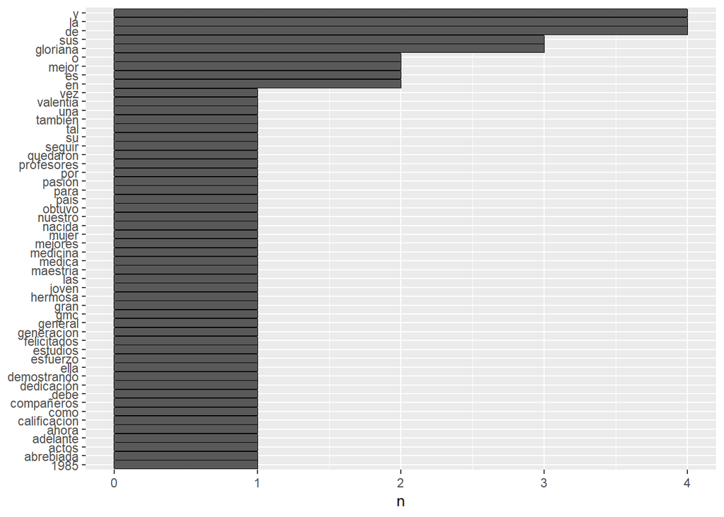

```r
conteo %>%
  count(word, sort = TRUE) %>%
 # filter(n > 600) %>%
  mutate(word = reorder(word, n)) %>%
  ggplot(aes(word, n)) +
  geom_bar(stat = "identity", color = "black", fill = "#87CEFA") +
  geom_col() +
  xlab(NULL) +
  coord_flip()
```

```r
text2 <- removeWords(text, words = c("en", "vez", "por", "las", "gran", "actos", "1985" ))

text2
```

```
## [1] "Gloriana, mujer joven y hermosa nacida   es una de -"
## [2] "mejores, o tal  la mejor medica general de nuestro pais. En-"
## [3] "sus estudios de maestria obtuvo la mejor calificacion de la-"
## [4] "generacion, y sus  quedaron felicitados  sus profesores y"
## [5] "compañeros. Ahora Gloriana debe seguir adelante demostrando su "
## [6] "valentia, esfuerzo, pasión y dedicación para la medicina."
## [7] "Ella es Gloriana, o también abrebiada como GMC."
```

Y sería volver a analizar el text2 con las palabras eliminadas…

### Otra tipo de recuento de datos

Ademas de analizar las palabras de forma individula, se podría analizar un tipo de palabra en específico, que haga refencia a una persona, o un grupo especial de personas. Por ejemplo, se podrían analizar Tweets sobre cierto candidato, y ver cuál promulagaba más campaña en las redes.

```r
tuits_afinn %>%
  count(Candidato)
```

```
## # A tibble: 5 x 2
##   Candidato         n
##   <chr>         <int>
## 1 JaimeRdzNL      525
## 2 JoseAMeadeK     533
## 3 lopezobrador_   183
## 4 Mzavalagc       838
## 5 RicardoAnayaC   617
```

```r
# Únicas
tuits_afinn %>%
  group_by(Candidato) %>%
  distinct(Palabra) %>%
  count()
```

```
## # A tibble: 5 x 2
## # Groups:   Candidato [5]
##   Candidato         n
##   <chr>         <int>
## 1 JaimeRdzNL      117
## 2 JoseAMeadeK     183
## 3 lopezobrador_    73
## 4 Mzavalagc       190
## 5 RicardoAnayaC   153
```

### Nube de Palabras estándar

Una nube de palabra se ve como sigue. Estos datos se obtienen a partir del apartado de la creación de la matriz de término.

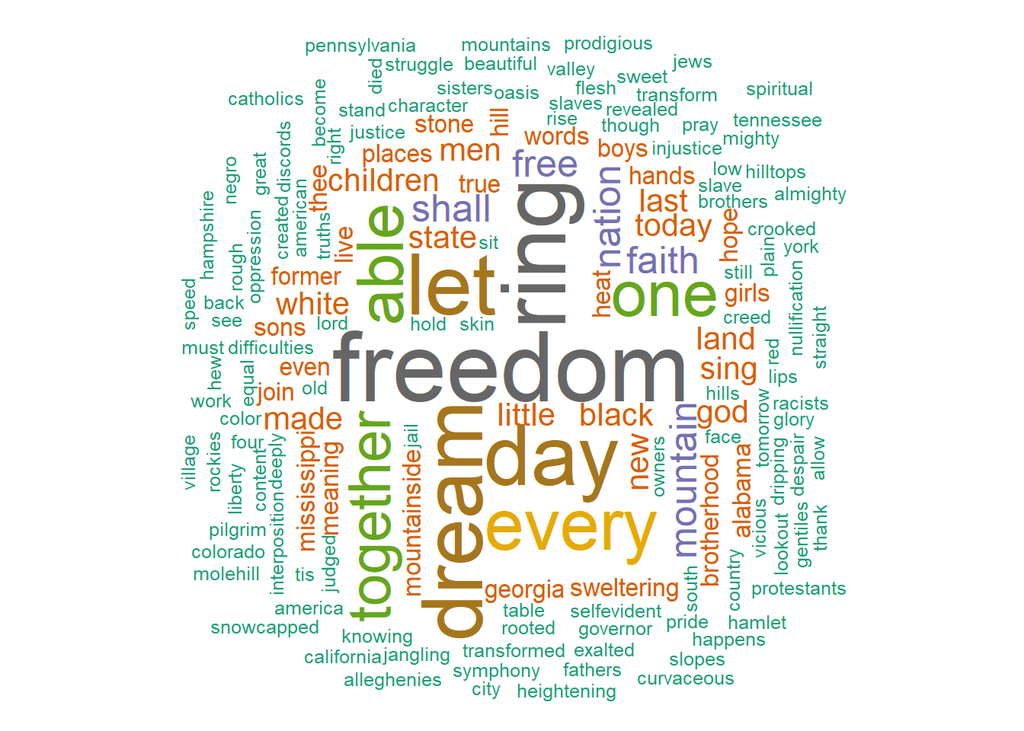

```r
set.seed(1234)
wordcloud(words = d$word, freq = d$freq, min.freq = 1,
          max.words=200, random.order=FALSE, rot.per=0.35,
          colors=brewer.pal(8, "Dark2"))
```

Casi siempre para crear una nube de palabra, se crea antes la matriz de término y luego la nube de palabra.

http://www.sthda.com/english/wiki/text-mining-and-word-cloud-fundamentals-in-r-5-simple-steps-you-should-know

### Nube de Palabras: carta de mujica

Para el análisis del discurso de Mojica, veamos las palabras más relevantes

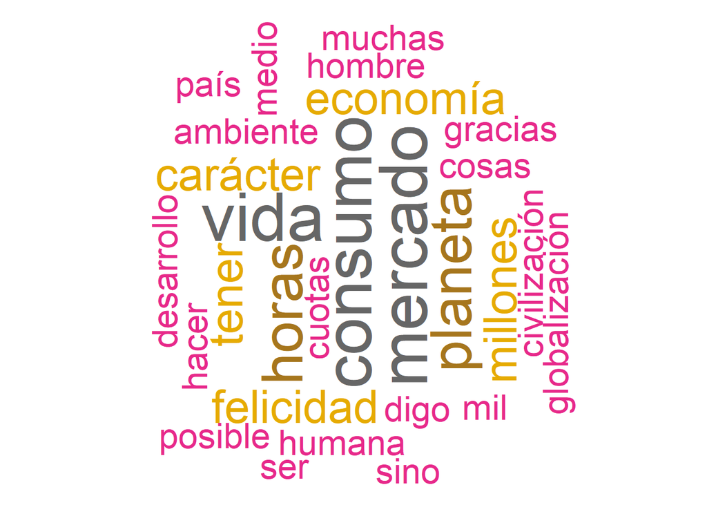

```r
wordcloud(term_document_data_frame$word, term_document_data_frame$freq,
          scale = c(4,.2), min.freq = 3, max.words = 60, random.order = FALSE,
          rot.per = .35, colors = brewer.pal(8,"Dark2"))
```

Según el discurso de Pepe, ¿cuáles fueron las palabras más relevantes?

### Nube de Palabras: Cartas de Obama y de Trump

Se podría ser más explícito y mejorar ciertos aspectos en las nubes de palabras.

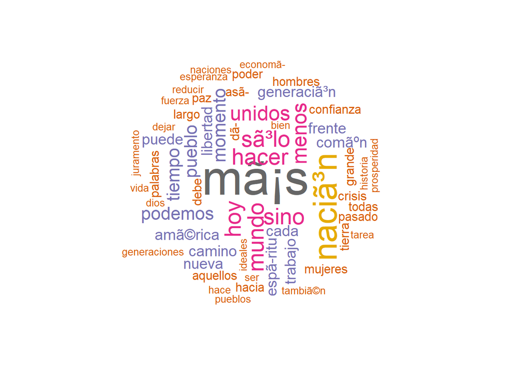

```r
wordcloud(term_document_data_frame.obama$word, term_document_data_frame.obama$freq,
          scale = c(4,.2), min.freq = 3, max.words = 60, random.order = FALSE,
          rot.per = .35, colors = brewer.pal(8,"Dark2"))
```

Las palabras que Obama pronunció más en su discurso son: mas, nación, unidos, mundo, hacer y hoy. Este habla de que los ciudadanos deben estar unidos en una sola nación que depende de la fe y la decisión del pueblo estadounidense

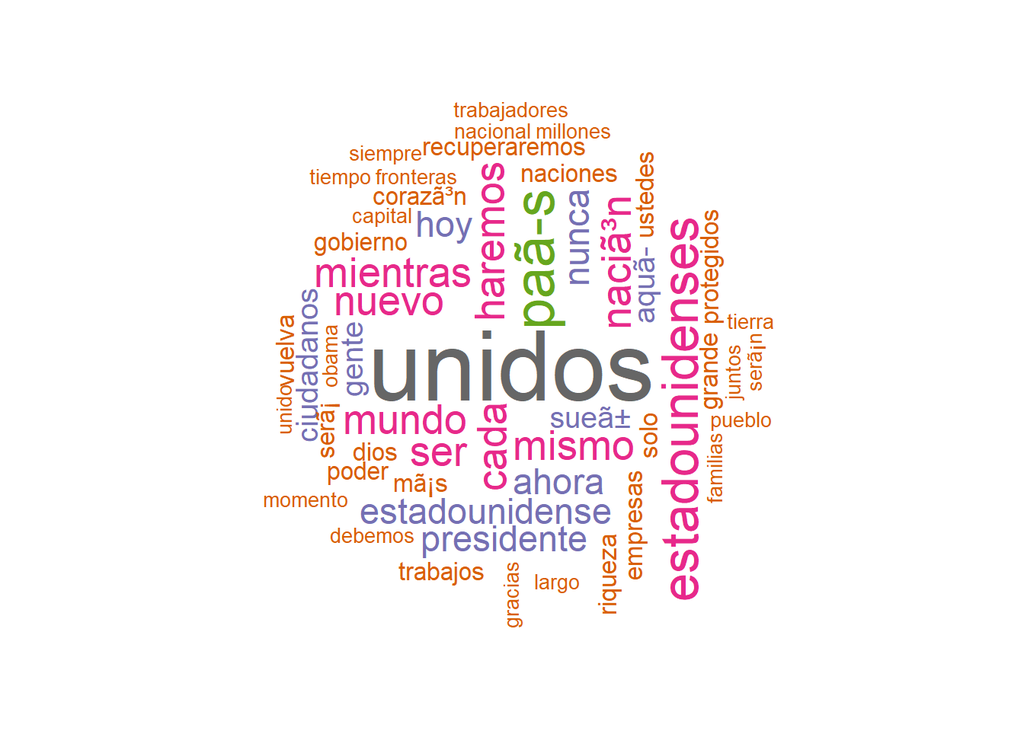

```r
wordcloud(term_document_data_frame.trump$word, term_document_data_frame.trump$freq,
          scale = c(4,.2), min.freq = 3, max.words = 60, random.order = FALSE,
          rot.per = .35, colors = brewer.pal(8,"Dark2"))
```

Las palabras que Trump mencionó más son: unidos, estadounidenses, pais, haremos, nacion, mundo, haremos. Trump dio un discurso bastante nacionalista y además hablando de varias cosas que haran como el gran país que son.

### Nube de Palabras: nube de palabras en común

```r
text <- data.frame(doc_id = c("Obama", "Trump"), text = c(obama, trump))
ds <- DataframeSource(text)
corpus <- Corpus(ds)
corpus
```

```
## <<SimpleCorpus>>
## Metadata:  corpus specific: 1, document level (indexed): 0
## Content:  documents: 2
```

```r
# Eliminar signos de puntuación
corpus <- tm_map(corpus,removePunctuation)
# Texto a minúsculas
corpus <- tm_map(corpus,tolower)
# Eliminar numeros
corpus <- tm_map(corpus,removeNumbers)
# Eliminar palabras vacías del idioma español
corpus <- tm_map(corpus, removeWords, stopwords("spanish"))
# Genera la matriz de términos
term_document_matrix <- TermDocumentMatrix(corpus)
term_document_matrix <- as.matrix(term_document_matrix)
colnames(term_document_matrix) <- c("Obama","Trump")
```

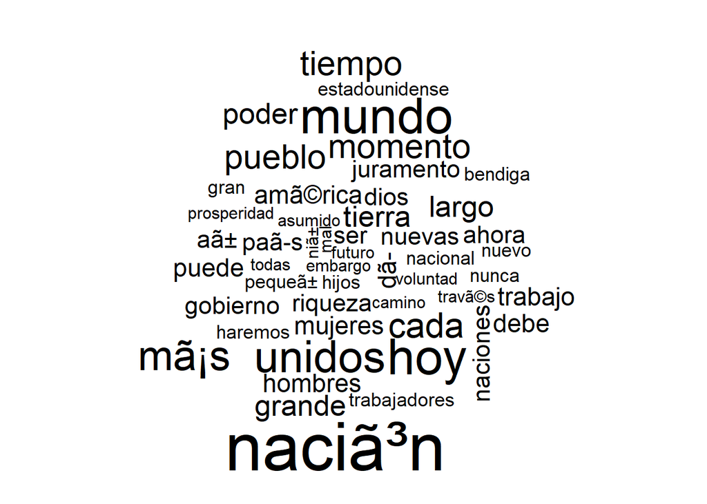

```r
commonality.cloud(term_document_matrix,
                  #comonality.measure = min,
                  max.words = 50)
```

## Análisis de sentimiento

### Palabras positivas y negativas

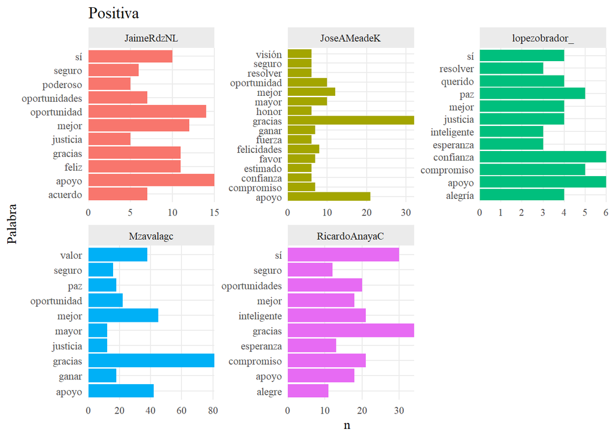

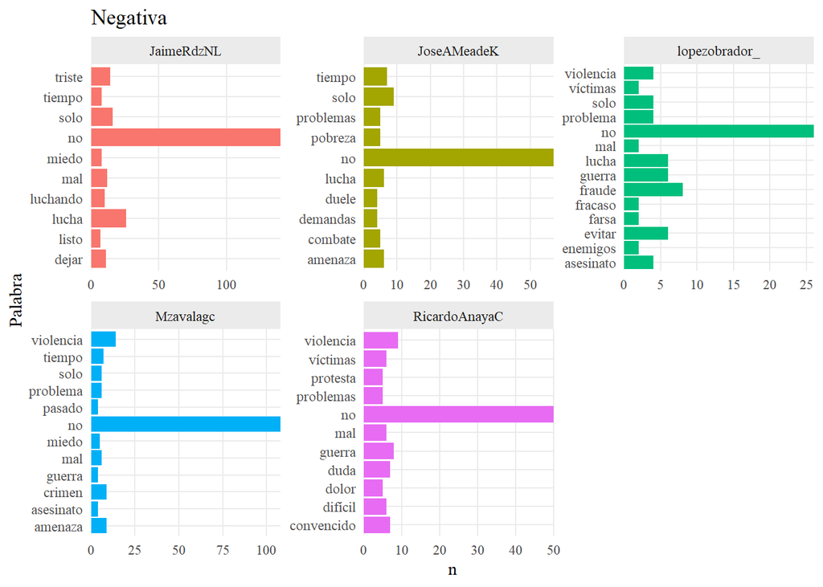

```r
#  Palabras positivas y negativas más usadas por cada uno de ellos, usando map()
# de purr, top_n() de  dplyr() y ggplot.

map(c("Positiva", "Negativa"), function(sentimiento) {
  tuits_afinn %>%
    filter(Tipo ==  sentimiento) %>%
    group_by(Candidato) %>%
    count(Palabra, sort = T) %>%
    top_n(n = 10, wt = n) %>%
    ggplot() +
    aes(Palabra, n, fill = Candidato) +
    geom_col() +
    facet_wrap("Candidato", scales = "free") +
    scale_y_continuous(expand = c(0, 0)) +
    coord_flip() +
    labs(title = sentimiento) +
    tema_graf
})
```

Se podría quitar la palabra NO, y ver los resultados (en el léxico, no podría confundir el análisis)

```r
tuits_afinn <-
  tuits_afinn %>%
  filter(Palabra != "no")
```

¿Qué podríamos observar?

### Tendencia de resultados

Como deseamos observar tendencias, vamos a obtener la media de sentimientos por día, usando group_by() y summarise() y asignamos los resultados a tuits_afinn_fecha

```r
tuits_afinn_fecha <-
  tuits_afinn %>%
  group_by(status_id) %>%
  mutate(Suma = mean(Puntuacion)) %>%
  group_by(Candidato, Fecha) %>%
  summarise(Media = mean(Puntuacion))
```

Veamos nuestros resultados con ggplot()

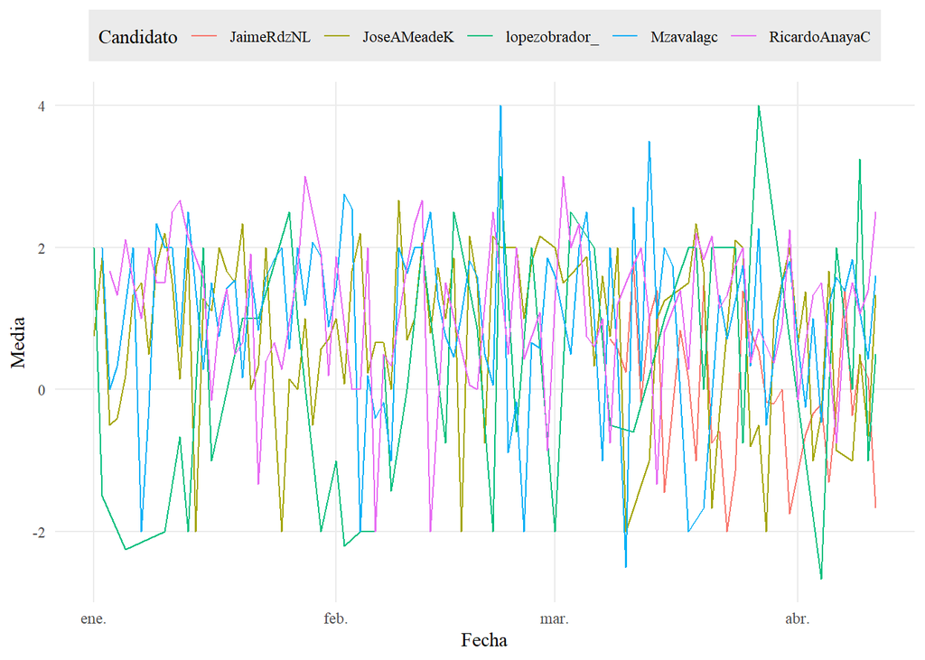

```r
tuits_afinn_fecha %>%
  ggplot() +
  aes(Fecha, Media, color = Candidato) +
  geom_line() +
  tema_graf +
  theme(legend.position = "top")
```

No nos dice mucho. Sin embargo, si separamos las líneas por candidato, usando facet_wrap(), será más fácil observar el las tendencias de los Candidatos.

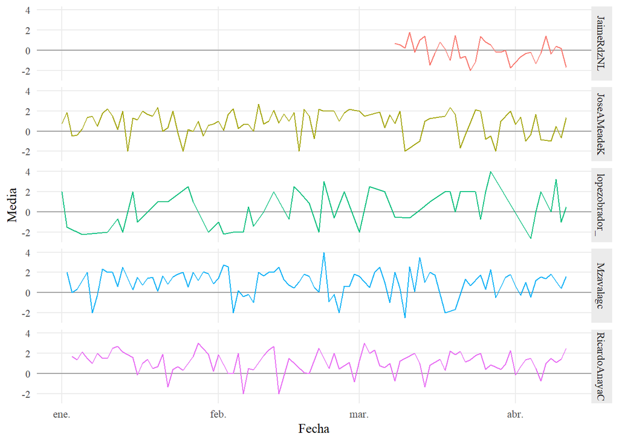

```r
tuits_afinn_fecha %>%
  ggplot() +
  aes(Fecha, Media, color = Candidato) +
  geom_hline(yintercept = 0, alpha = .35) +
  geom_line() +
  facet_grid(Candidato~.) +
  tema_graf +
  theme(legend.position = "none")
```

### Comparando los sentimientos negativos y positivos

Veamos si hacer una comparación entre lo bueno y lo malo

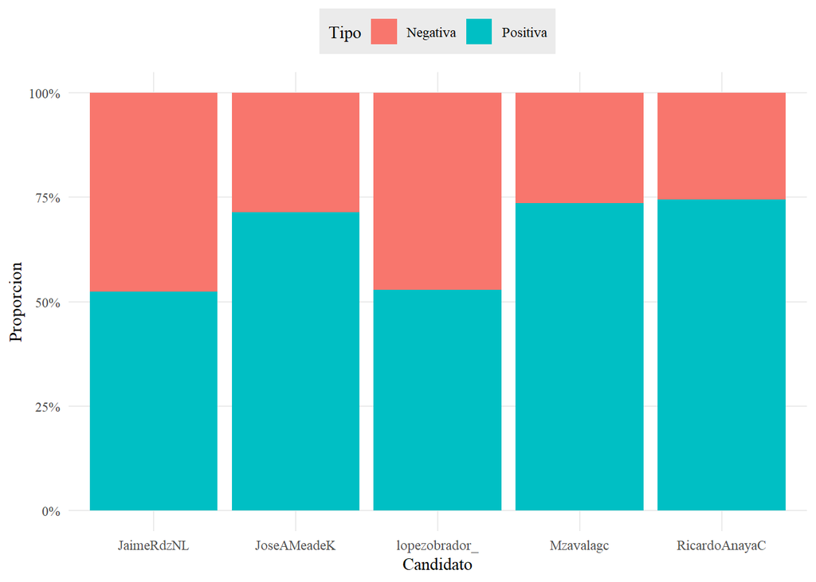

```r
tuits_afinn %>%
  count(Candidato, Tipo) %>%
  group_by(Candidato) %>%
  mutate(Proporcion = n / sum(n)) %>%
  ggplot() +
  aes(Candidato, Proporcion, fill = Tipo) +
  geom_col() +
  scale_y_continuous(labels = percent_format()) +
  tema_graf +
  theme(legend.position = "top")
```

Otra forma…

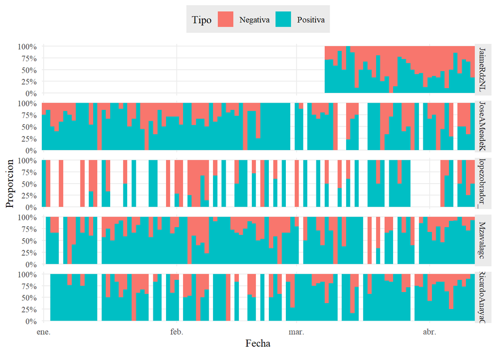

```r
tuits_afinn %>%
  group_by(Candidato, Fecha) %>%
  count(Tipo) %>%
  mutate(Proporcion = n / sum(n)) %>%
  ggplot() +
  aes(Fecha, Proporcion, fill = Tipo) +
  geom_col(width = 1) +
  facet_grid(Candidato~.) +
  scale_y_continuous(labels = percent_format()) +
  scale_x_date(expand = c(0, 0)) +
  tema_graf +
  theme(legend.position = "top")
```

### Bloxplots y densidades (diagrama caja y bigotes)

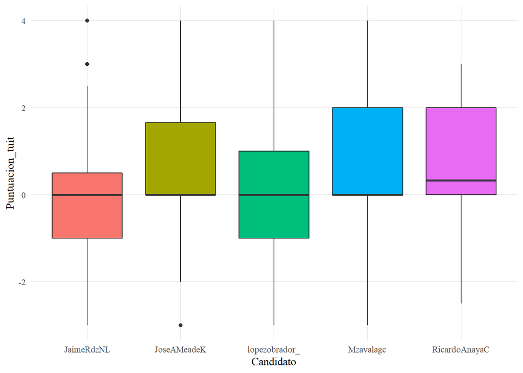

```r
tuits %>%
  ggplot() +
  aes(Candidato, Puntuacion_tuit, fill = Candidato) +
  geom_boxplot() +
  tema_graf
```

Veamos una versión del Bloxplots en el tiempo

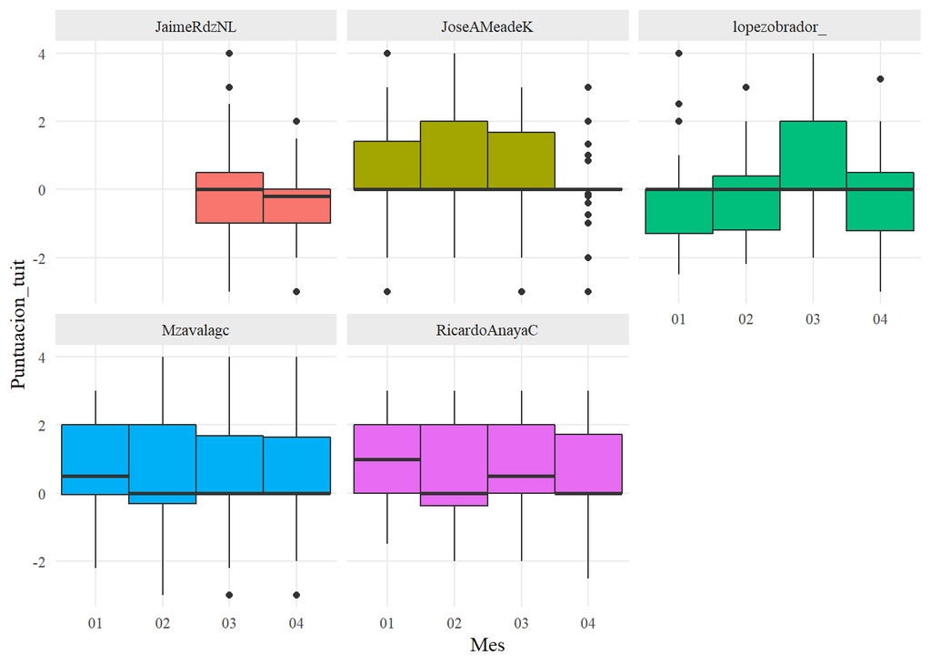

```r
tuits %>%
  mutate(Mes = factor(Mes)) %>%
  ggplot() +
  aes(Mes, Puntuacion_tuit, fill = Candidato) +
  geom_boxplot(width = 1) +
  facet_wrap(~Candidato) +
  tema_graf +
  theme(legend.position = "none")
```

Veamos una Tendencia de sentimientos usando densidades

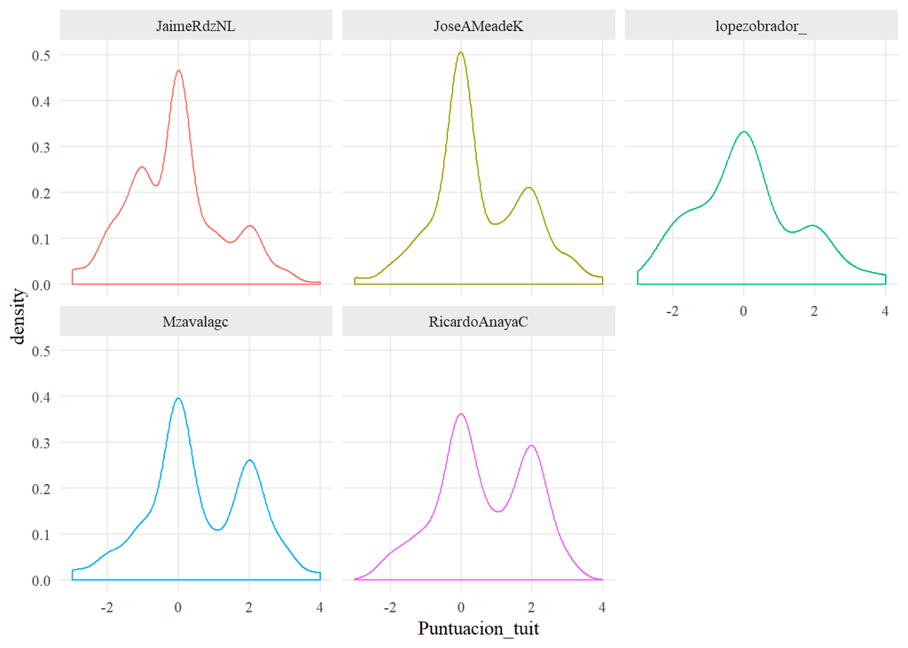

```r
tuits %>%
  ggplot() +
  aes(Puntuacion_tuit, color = Candidato) +
  geom_density() +
  facet_wrap(~Candidato) +
  tema_graf
```

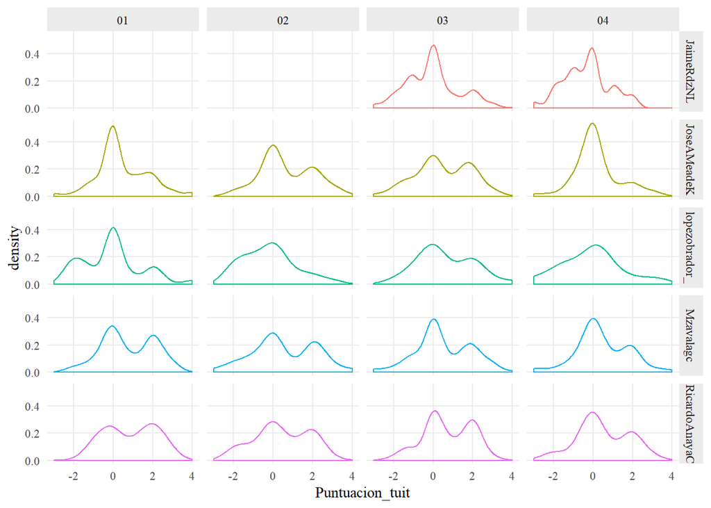

```r
tuits %>%
  ggplot() +
  aes(Puntuacion_tuit, color = Candidato) +
  geom_density() +
  facet_grid(Candidato~Mes) +
  tema_graf
```

¿Qué podemos concluir?

## Otros análisis

### Clusterring en la descripción o exploración de las palabras

Y pues si, acá también podemos agrupar palábras. Qué éxito!

[output not shown]

```
## <<TermDocumentMatrix (terms: 8168, documents: 1580)>>
## Non-/sparse entries: 25224/12880216
## Sparsity           : 100%
## Maximal term length: 27
## Weighting          : term frequency (tf)
```

```
## [1] 8168 1580
```

[figure not shown]

[output not shown]

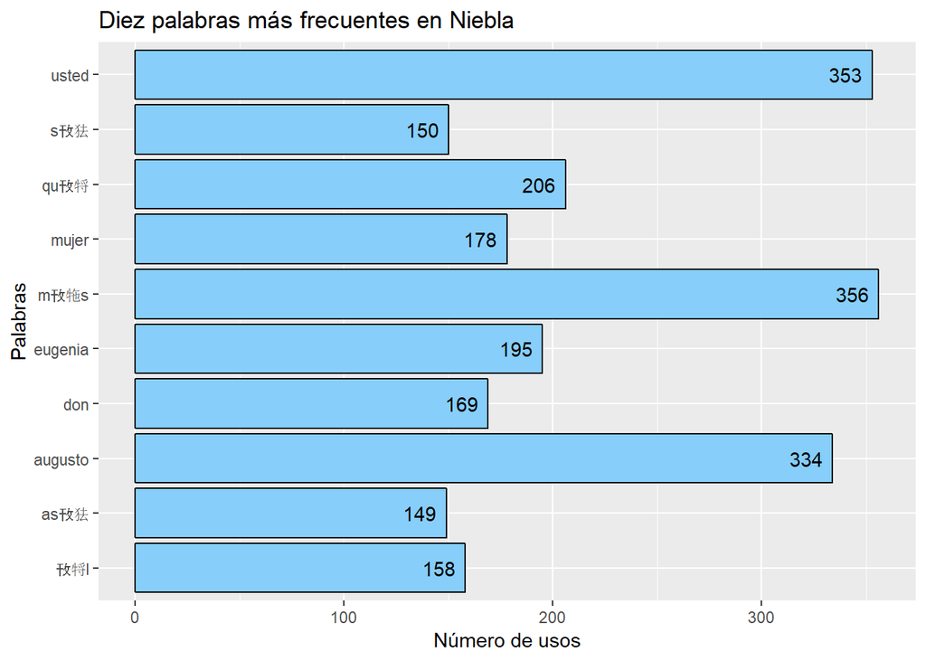

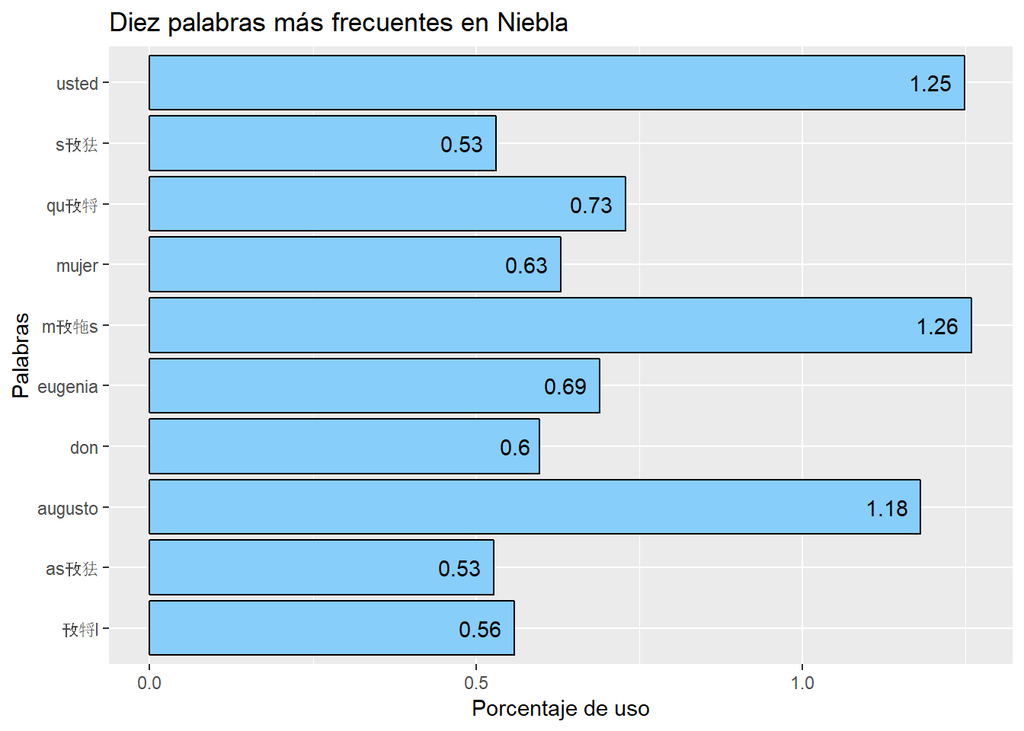

[output not shown]